# Workshop 18 [Week 8]: Model evaluation and violations

# Fit an lm with continuous predictor

## Model with continuous predictor

We can predict rts as a function of age. We can do this with age as continuous variable.

```r
model <- lm(rt ~ age, data = data)
```

### 1. Question

Hang on. Before fitting a parametric model we need to make sure our outcome variable is continuous.

- Is the outcome variable continuous?
  - **Answer:** yes but …
- What’s a reason for why rt might not be perfectly continuous (nothing is in practice)?
  - **Answer:** rts have a lower bound of 0.

### 2. Question

How does age affect the rts?

```r
summary(model) # Answer in age row; slowdown of 5.38 msecs per year
```

```
Call:
lm(formula = rt ~ age, data = data)

Residuals:
    Min      1Q  Median      3Q     Max
-375.90  -96.01  -31.83   52.73 1288.92

Coefficients:
            Estimate Std. Error t value Pr(>|t|)
(Intercept) 340.5738    25.8198   13.19   <2e-16 ***
age           5.3796     0.4389   12.26   <2e-16 ***
---
Signif. codes:  0 '***' 0.001 '**' 0.01 '*' 0.05 '.' 0.1 ' ' 1

Residual standard error: 171.3 on 351 degrees of freedom
Multiple R-squared:  0.2997,    Adjusted R-squared:  0.2977
F-statistic: 150.2 on 1 and 351 DF,  p-value: < 2.2e-16
```

### 3. Extract residuals

We can extract the model residuals like so and assign them to a new column called `residuals`:

```r
data <- mutate(data, residuals = residuals(model))
# If tidyverse doesn't work for you, use
# data$residuals <- residuals(model)
```

### 4. Check out residuals

Have a look at the residuals column.

```r
data
```

```
# A tibble: 353 x 6
      id   age age_2     age_3        rt residuals
   <dbl> <dbl> <chr>     <chr>     <dbl>     <dbl>
 1     1    84 old-ish   old-ish    702.     -90.8
 2     2    37 young-ish young-ish  471.     -69.0
 3     3    62 old-ish   middle     639.     -35.4
 4     4    85 old-ish   old-ish    708      -89.8
 5     5    73 old-ish   old-ish    607.    -126.
 6     6    65 old-ish   middle     542.    -149.
 7     7    30 young-ish young-ish  571.      68.7
 8     8    49 young-ish middle     509.     -94.8
 9     9    83 old-ish   old-ish    737.     -50.4
10    10    58 young-ish middle     550.    -103.
# … with 343 more rows
```

What should be mean of the residuals ideally be? Calculate the mean of the residuals using `describe`.

```r
#describe(data = data, mean = xxx(xxx))
```

```r
describe(data = data, mean = mean(residuals)) # answer
```

```
# A tibble: 1 x 1
      mean
     <dbl>
1 1.13e-16
```

Is this what you would expect?

**Answer:** Absolutely. The mean of the residuals should ideally be 0.

## Normality of residuals

If our model meets the normality assumption we would expect the residuals to be normal distributed.

### 1. Task

Create a histogram of the residuals with 30 bins.

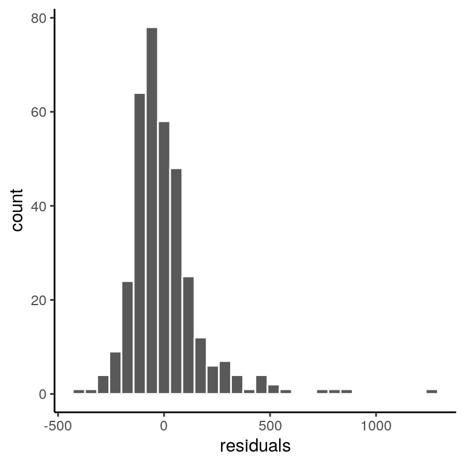

```r
histogram(data = data, x = residuals, bins = 30) # answer
```

Optional: check the skewness by running:

```r
# install.packages("moments")
# library(moments)
# skewness(data$residuals)
```

Do you think there are reasons to be concerned about the skewness?

### 2. Task

To correct for the normality violation, we can use a log transformation of the rts (Baayen, 2008). Replace the **xxx**s below to transform the rts and store them in `log_rt`.

```r
# data <- mutate(data, log_rt = log(xxx))
```

```r
data <- mutate(data, log_rt = log(rt)) # answer
```

### 3. Task

Refit `model` this time with `log_rt` as outcome variable.

```r
# model <- lm(xxx ~ age, data = data)
```

```r
model <- lm(log_rt ~ age, data = data) # answer
```

### 4. Task

Check the model summary.

```r
summary(model) # answer
```

```
Call:
lm(formula = log_rt ~ age, data = data)

Residuals:
    Min      1Q  Median      3Q     Max
-0.6360 -0.1259 -0.0243  0.1068  1.0061

Coefficients:
             Estimate Std. Error t value Pr(>|t|)
(Intercept) 5.9938829  0.0320413  187.07   <2e-16 ***
age         0.0076890  0.0005447   14.12   <2e-16 ***
---
Signif. codes:  0 '***' 0.001 '**' 0.01 '*' 0.05 '.' 0.1 ' ' 1

Residual standard error: 0.2125 on 351 degrees of freedom
Multiple R-squared:  0.3621,    Adjusted R-squared:  0.3603
F-statistic: 199.2 on 1 and 351 DF,  p-value: < 2.2e-16
```

Because the age effect is now on a log-scale we have to think about the slope as showing “with an increase of 1 year of age the rts are 0.008 times longer than the intercept.”